# 2017 Tour Evaluation

UWAA Tours

The data is collected from the Jan-Oct 2017 trip evaluations on WUFOO website. The purpose of this resport is demostrating the satisfaction from the travelers who joined UWAA Tours Departemnt’s trips, and helping team members better understand the travelers’ feedback. Since the data has only been collected from the trips in Jan-Oct 2017, this report does not represent the entire year 2017.

# Table 1: Result by Questions in Tour Evaluation

*Table 1* shows the percentage of each satisfaction category based on each type of question.The eight questions we are interested in are: Overall Assessment, Tour Itinerary, Tour Director, Lecture/Host, Tour Hotel, Tour Ship, Tour Meal, and Tour Staff. The row Average at the bottom indicates the overall satisfaction through the year.

|  | TourEvaluation | Excellent | VeryGood | Good | Fair | Poor |
| --- | --- | --- | --- | --- | --- | --- |
| 1 | overall_assessment | 70.22% | 24.45% | 3.76% | 0.94% | 0.63% |
| 2 | tour_itinerary | 65.82% | 27.85% | 5.38% | 0.95% | NA |
| 3 | tour_director | 79.81% | 14.51% | 3.79% | 1.58% | 0.32% |
| 4 | lecture_host | 80.59% | 13.50% | 3.80% | 2.11% | NA |
| 5 | tour_hotel | 59.65% | 32.02% | 7.02% | 0.88% | 0.44% |
| 6 | tour_ship | 70.00% | 19.09% | 9.09% | 0.91% | 0.91% |
| 7 | tour_meal | 51.42% | 37.85% | 8.20% | 2.21% | 0.32% |
| 8 | tour_staff | 60.00% | 31.48% | 5.25% | 1.97% | 1.31% |
|  | Average | 67.19% | 25.09% | 5.79% | 1.44% | 0.65% |

# Table 2: Result by Individual Tour Operators

*Table 2* shows the percentage of each satisfaction category based on each tour operators. The six operators are: AHI, GHG, GON, ODY, ORB, and SET. The column Total represents how many feedbacks each tour operators got through the year. Each satisfaction rating is the average rating of all the tips hold by each spercific operator.

| tour_operator | Total | Excellent | VeryGood | Good | Fair | Poor |
| --- | --- | --- | --- | --- | --- | --- |
| AHI | 446 | 56.05% | 18.83% | 23.54% | 1.12% | 0.45% |
| GHG | 71 | 38.03% | 23.94% | 35.21% | 2.82% | 0.00% |
| GON | 437 | 52.86% | 20.82% | 23.80% | 2.06% | 0.46% |
| ODY | 1486 | 52.76% | 20.93% | 25.10% | 0.81% | 0.40% |
| ORB | 164 | 53.05% | 19.51% | 25.61% | 1.83% | 0.00% |
| SET | 99 | 56.57% | 19.19% | 23.23% | 1.01% | 0.00% |

Here are bar plots helps compare the satisfactions among different operators.

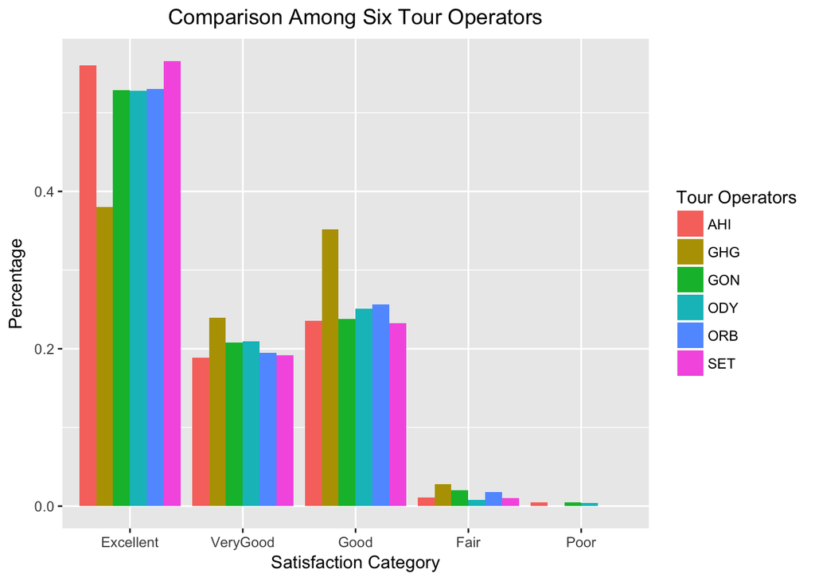

# Table 3: Result by Individual Trips

*Table 3* shows the percentage of each satisfaction category based on each tips. We had 44 trips through January to October 2017. Each row indicates each unique trip, and the name is formed by “placename.monthdate” (if the trip took place only once in the year, then it’s marked “placename.17”). Same as *Table 2*, the column Total represents the total number of feedbacks we received in each trip.

[output not shown]

Here is a bar chart showing the percentage of “Excellent” in each trip.

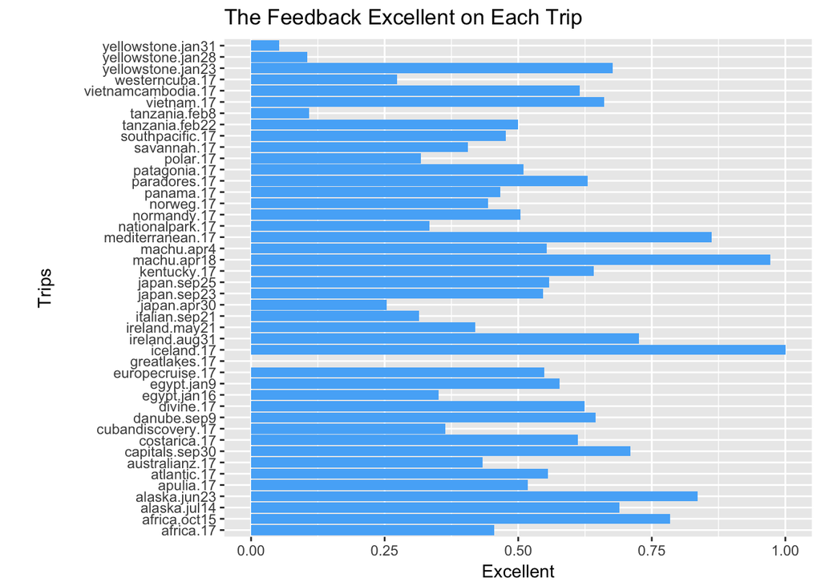

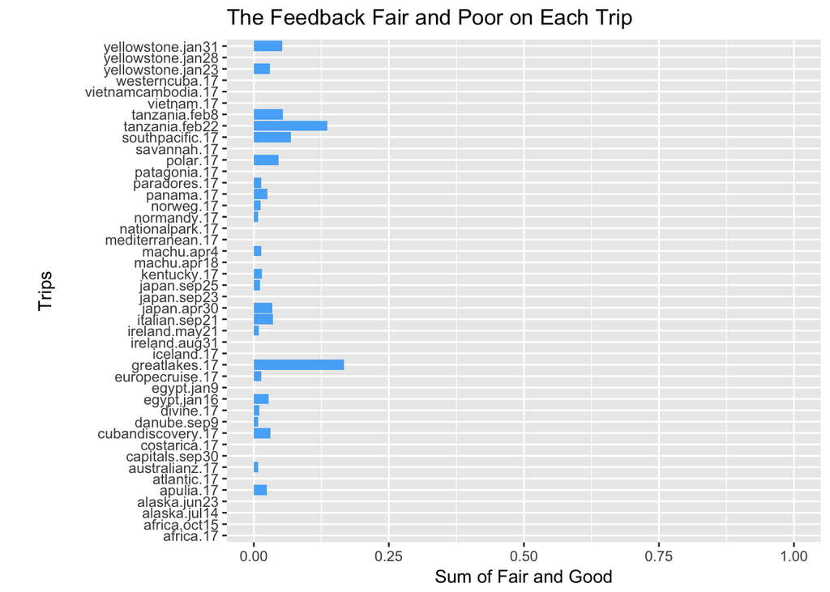

# Futher Improvement

- The satisfactions of lecture and host are combined as lecture_host. The number of result is not accurate enough.